# Spatial Coronavirus

Biol355

3/13/2020

## The world!

For today, I’ve given you a number of shapefiles associated with worldmaps, state maps of the US, and county maps of Massachusetts and the coronavirus. You can download the data here. I’d like you to take a gander and think about what you can do with them.

To start with, let’s take a look at the world.

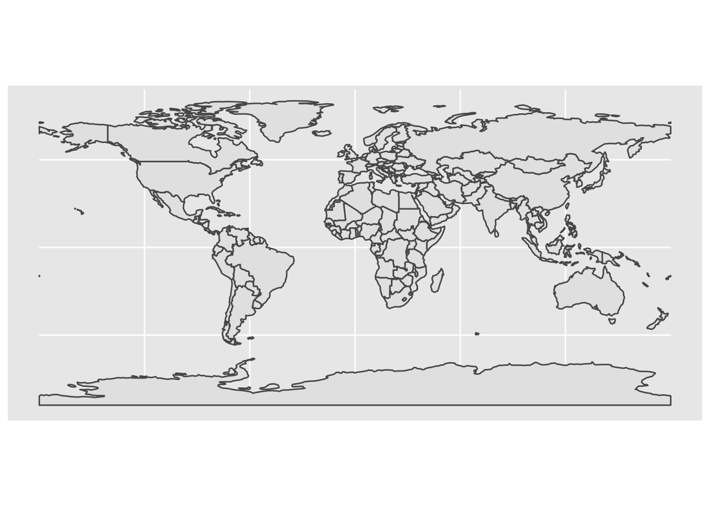

```r
library(sf)
library(ggplot2)

worldmap <- st_read("./data/coronavirus_shapefiles/worldmap.shp")
ggplot(worldmap) +
  geom_sf() +
  coord_sf()
```

That’s a nice example workflow for loading and plotting one single shapefile. The shapefiles I have given you have multiple rows for dates, geospatial areas, and different case types (confirmed, death, recovered). You should be somewhat familiar with this already.

## Available Shapefiles

- worldmap.shp - A map of the world with country boundaries.
- us.shp - A map of the US with state boundaries.
- ma_county_maps.shp - A map of Massachusetts with county boundaries.
- coronavirus_points.shp - The coronavirus dataset with each lat/long as a POINT.
- coronavirus_polys.shp - The coronavirus dataset with each case in a country POLYGON.
- ma_counties_coronavirus.shp - The coronavirus dataset for Massachusetts with each case as a polygon in a MA county.
- usa_coronavirus_points.shp - All coronavirus data in the US represented as POINTS.
- usa_coronavirus_polygons - All coronavirus data in the US represented as POLYGONS. You have a number of available shapefiles for use. Here they are

## Lab Exercises

With that in mind, I’d like you to -

1. Plot the spatial distribution of coronavirus cases. Color by date.
2. Show the distribution of mortality across the world by country using polygons.
3. Within the US, show the total confirmed cases of coronavirus across the country by state. Feel free to use points or polygons here.
4. Show the progression of conformed coronavirus in Massachusetts spatially over time using facets and dates.
5. Take the map above you liked the most and reproject it! Do something cool and funky looking!